# Security Crises and Executive Approval

Chapter 5 of the book manuscript *Rally or Reprimand?*  
APSA Annual Meeting · September 2026

Ryan Carlin · Timothy Hellwig · Will Horne · Gregory Love · Cecilia Martínez-Gallardo · Matthew Singer

## Three Security Crises

**September 11, 2001**  
Approval 51 → 86 in five days. *Rally.*

**Madrid, March 2004**  
Deadliest attack in Spain’s history; government out three days later. *Reprimand.*

**Türkiye, 1991 & 1995**  
Recurrent PKK attacks blamed on the incumbent. *Reprimand.*

**What separates them?**

Photos: Ground Zero, Sept. 14, 2001; Atocha station, March 2004.

[figure not shown]

[figure not shown]

## What we know: three schools, no complete framework

Mueller (1970): rallies follow events that are *“specific, dramatic, and sharply focused.”*

| School | Mechanism | What it misses |
| --- | --- | --- |
| **Affective** | Threat, patriotism, out-group hostility | Why salient attacks end in *reprimand* |
| **Rationalist** | Performance judgment; casualties | Casualties weighed inconsistently |
| **Opinion leadership** | Opposition restraint → no criticism in the news (Brody 1991) | Direct measures of elite conflict |

## The salience–conflict framework (Chapter 2)

**1. Salience is a necessary condition.**  
No public attention → no movement, whatever the severity.

**2. Given salience, elite conflict decides the direction.**  
Elites speak in one voice → *rally*.  
Elites clash openly → *unchanged or reprimand*.

**3. Conflict also influences duration.**  
The rally lasts while conflict stays suppressed.

Conflict is measured **two-sided**: government ↔︎ opposition.

## Which crises suppress elite conflict?

Blame turns on **plausible exogeneity** (Hellwig et al. forthcoming).

| More plausibly exogenous | → | Less plausibly exogenous |
| --- | --- | --- |
| Attack directed from abroad | Wars, incl. wars of choice | Domestic, recurring violence |
| Restraint; rally most likely | Debated from day one | Blame easy; conflict baseline high |

**Expect:** rallies after international attacks and interstate wars; reprimand, or nothing, where violence is homegrown.

Terrorism is coded by the origin of its perpetrators, not the location of the attack.

## Do discrete security events move approval?

EAD: monthly approval, 35 countries · CED: validated security events (20+ deaths; GTD, ICB, UCDP)

959

discrete security events

~3%

of country-months see an onset

15%

of country-months under an ongoing crisis

## Event results: onsets rally — but only interstate ones

- Onset lifts approval: **+0.45***
- All of it interstate: **+1.18***** — terrorism: n.s.
- Severity (fatalities): **little**, interstate only
- Rarity: **bigger rallies after long calm**
- Ongoing crises: **no average effect**

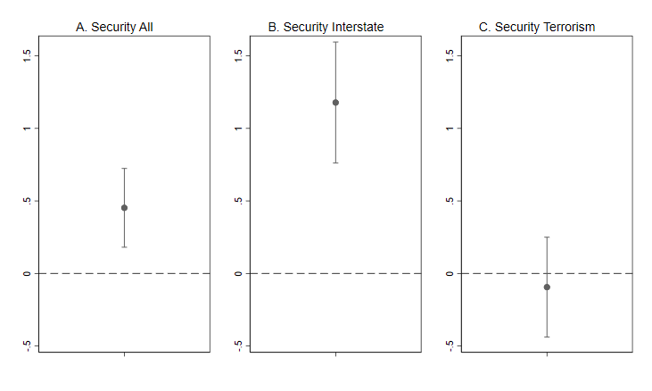

## Measure what the public receives

News-based measures, by crisis type:

- **Salience** = crisis articles mentioning the executive ÷ all articles
- **Elite conflict** = share of coverage paragraphs with government–opposition conflict *(months with 10+ paragraphs)*
- **Searched sample** = 100+ archived articles that month; empty searches are true zeros *(24 countries)*
- **War** = estimated within war coverage months

## War: salience rallies while elites hold their fire

| (t−1) | Any security | War | Terrorism |
| --- | --- | --- | --- |
| Elite conflict | −1.86* | +2.75* | −1.59* |
| Salience | +9.25* | **+105.1*** | +9.60 |
| Conflict × Salience | −24.1 | **−756.2*** | −17.7 |
| N (countries) | 4,961 (24) | 643 (4) | 4,961 (24) |

Table 5.6. CRE GLS, lagged DV, clustered SEs. * p ≤ .05. War: AUS, FRA, UK, US.

**The rally dissapears at ~15% conflict**

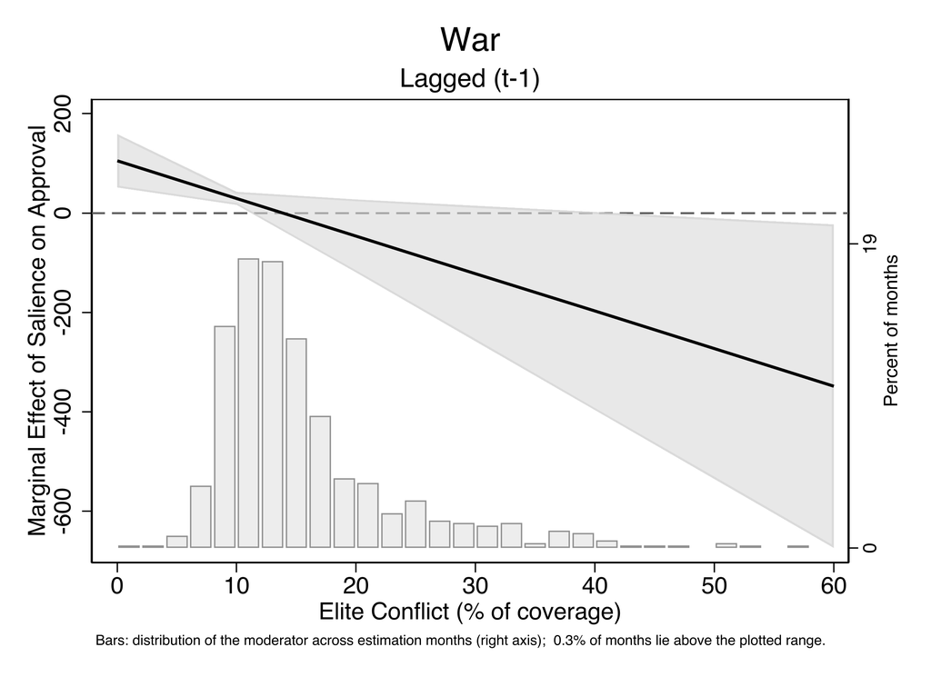

## Terrorism: Exogeniety Matters

| (t−1) | Domestic | International |
| --- | --- | --- |
| Elite conflict | **−2.11*** | −0.92 |
| Salience | +7.84 | **+103.3*** |
| Conflict × Salience | +13.9 | **−635.7*** |
| N (countries) | 4,961 (24) | 4,961 (24) |

Table 5.7. Same specification, searched sample. * p ≤ .05.

**International = war’s pattern. Domestic = reprimand only.**

International estimates lean heavily on the US.

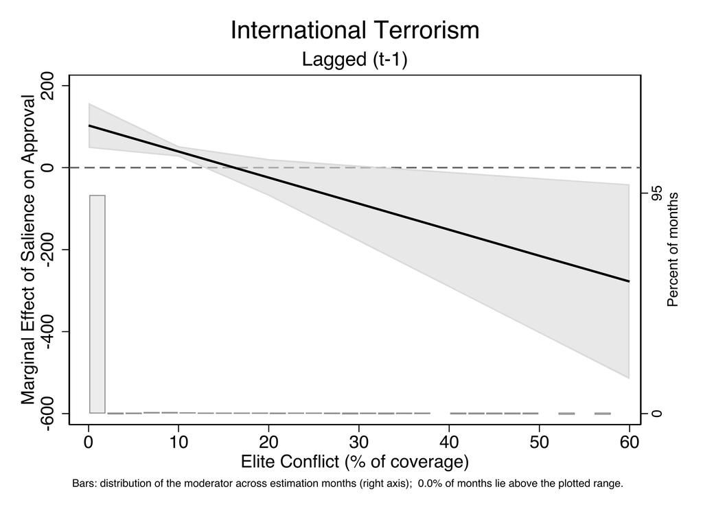

## Case Study: the United States

|  | Aug 1998 | Sep 2001 |
| --- | --- | --- |
| Salience | thin | **2.1%** — highest in our data |
| Elite conflict | **8%** | **4%** |
| Approval | no move | **47.6 → 63.5** |

Conflict returns — **9% by December** — and the rally decays.

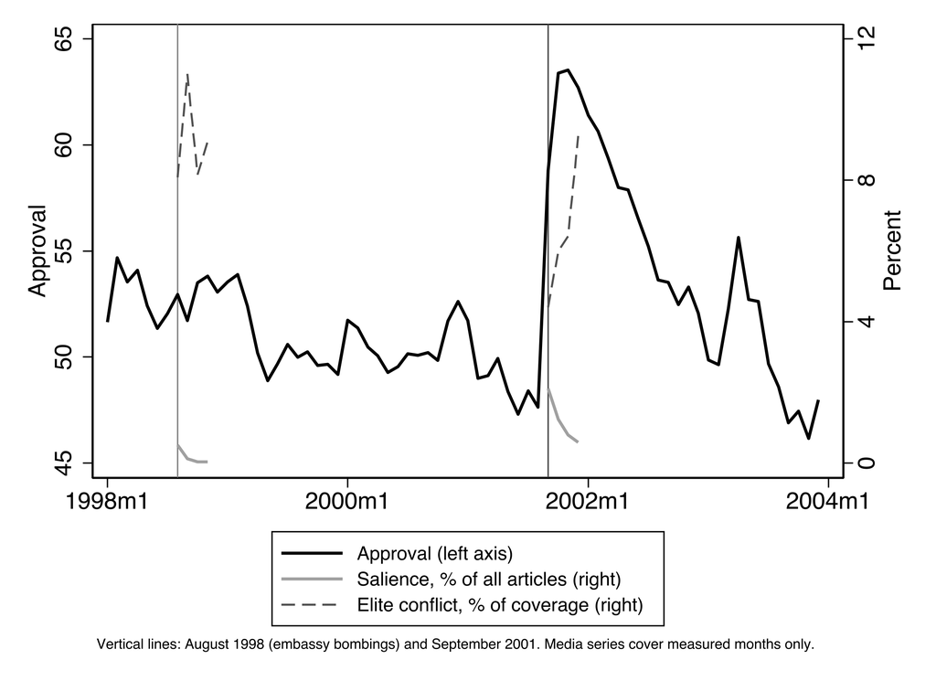

## Conclusions

- **Salience is necessary; elite conflict decides the direction.**
- Events: interstate onsets rally; severity adds little; **rarity matters**.
- The gradient holds: **international terrorism and war rally (conditionally); domestic violence only reprimands.**
- The US around 9/11: **highlights the mechanism, month by month.**

## This chapter in the book

**Ch. 2** theory → **Ch. 3** experimental results → **Ch. 4** measures → **Ch. 5 security** → **Ch. 6** health → **Ch. 7** natural disaster → **Ch. 8** economic

- Security: where rally conditions are **strongest** — outside threat, informational advantage, wary opposition.
- Health (Ch. 6): same logic, rally window **twice as wide** (28% vs. 14%).

**One framework, one set of measures, applied across crisis domains.**

## Thank you

## Backup — The conflict screen doesn’t drive the war result

| Screen (min. paragraphs) | none | 5+ | **10+** | 15+ | 20+ | 30+ |
| --- | --- | --- | --- | --- | --- | --- |
| Conflict × Salience | −508.5 | −550.0 | **−756.2*** | −766.8* | −791.7* | −878.3* |
| (SE) | (356.7) | (350.1) | (321.8) | (333.3) | (328.7) | (316.9) |
| N | 651 | 650 | 643 | 637 | 634 | 627 |

Appendix Table 5A.3: the featured war model with conflict screened at each column’s minimum paragraph count. A share computed from a handful of paragraphs is mostly sampling noise; the estimate is stable for any screen from ten paragraphs up and strengthens as reliability rises — the errors-in-variables signature.

## Backup — War on the searched sample

|  | War (t) | War (t−1) |
| --- | --- | --- |
| Elite conflict | −0.71* | +0.43 |
| Salience | **+123.7*** | +47.5 |
| Conflict × Salience | −804.7 | −428.0 |
| N (countries) | 4,985 (24) | 4,961 (24) |

Appendix Table 5A.2: war re-estimated on the 24-country searched sample, months without war coverage as zeros. Salient war coverage still lifts approval contemporaneously; the interaction attenuates, as expected when wartime months are pooled with months carrying no measurable war signal.